# Analyse des données SID/SuperSID

Le logiciel SuperSID enregistre les fichiers audio sous forme de tableaux avec extension "**.csv**". L'ordinateur est connecté à internet de sorte que son horloge est synchronisée par un serveur de temps avec une précision de quelques dizaines de millisecondes.

## Fichiers à valeurs séparées par des virgules (CSV)

Un format de fichier très commun pour les fichiers de données sont les valeurs séparées par des virgules (CSV) ou un format connexe tel que TSV (valeurs séparées par des onglets). Pour lire les données de ce fichier dans les tableaux Numpy, nous pouvons utiliser la fonction numpy.genfromtxt. Par exemple:

```python
import numpy as np
```

### Visualisez un fichier de données

Nous allons maintenant charger les données SID (amplitude du signal) dans une liste en utilisant la méthode `loadtxt` de la bibliothèque numérique `numpy`.

```python
np.loadtxt?
```

```python
NomFichier="data_SID/20120601_000000_NAA_S-0239.csv"
```

```python
data= np.loadtxt(NomFichier, comments='#', delimiter=",", skiprows=12, usecols=[1])
```

```python
print(data)
```

```
[ 1.27   1.191  1.191 ...,  1.152  1.074  1.016]
```

```python
print(len(data))
```

```
17280
```

```python
data_length = len(data)
time_data= np.arange(0.0, 24.0 , 24.0/(data_length))
```

```python
import matplotlib.pyplot as plt
```

```python
fig=plt.figure(figsize=(6,5))
plt.plot(time_data, data, label=NomFichier)
plt.xlabel("Temps (Heure en TU)")
plt.ylabel("Amplitude (V)")
plt.title("Signal NAA (24 KHz) enregistré le %s"%NomFichier)
```

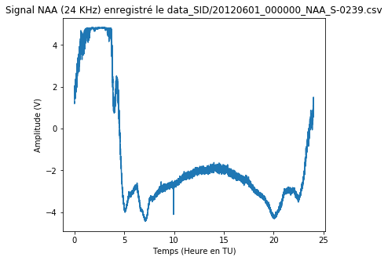

```python
plt.show()
```

```python
# %load programs/PlotSID.py

import numpy as np
import matplotlib.pyplot as plt
def PlotSID(NomFichier=""):
    data= np.loadtxt(NomFichier, comments='#', delimiter=",", skiprows=12, usecols=[1])
    data_length = len(data)
    time_data= np.arange(0.0, 24.0 , 24.0/(data_length))
    fig=plt.figure(figsize=(10,5))
    plt.plot(time_data, data, label="NAA")
    plt.xlabel("Temps (Heure en TU)")
    plt.ylabel("Amplitude (V)")
    plt.title("%s" %NomFichier)
    plt.legend()
    plt.show()
```

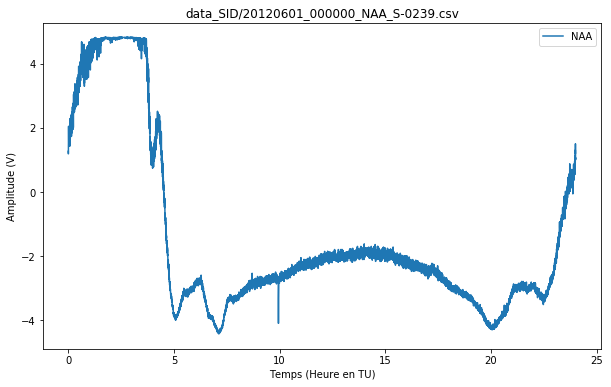

```python
PlotSID(NomFichier="data_SID/20120601_000000_NAA_S-0239.csv")
```

### Visualiser tous les fichiers de données

```python
import glob
FileList=glob.glob("data_SID/*.csv")
SID_Juin=[]
for filename in FileList:
    print(filename)
    data=np.loadtxt(filename, comments='#', delimiter=",", skiprows=12, usecols=[1])
    print(len(data))
    if len(data)==17280:
        SID_Juin.append(data)
```

```
data_SID\20120601_000000_NAA_S-0239.csv
17280
data_SID\20120605_000000_NAA_S-0239.csv
17280
data_SID\20120606_000000_NAA_S-0239.csv
17280
data_SID\20120607_000000_NAA_S-0239.csv
17280
data_SID\20120608_000000_NAA_S-0239.csv
17280
data_SID\20120609_000000_NAA_S-0239.csv
17280
data_SID\20120610_000000_NAA_S-0239.csv
17280
data_SID\20120611_000000_NAA_S-0239.csv
17280
data_SID\20120612_000000_NAA_S-0239.csv
17280
data_SID\20120613_000000_NAA_S-0239.csv
17280
data_SID\20120614_000000_NAA_S-0239.csv
17280
data_SID\20120615_000000_NAA_S-0239.csv
17280
data_SID\20120616_000000_NAA_S-0239.csv
17280
data_SID\20120617_000000_NAA_S-0239.csv
17280
data_SID\20120618_000000_NAA_S-0239.csv
17280
data_SID\20120619_000000_NAA_S-0239.csv
17280
data_SID\20120620_000000_NAA_S-0239.csv
17280
data_SID\20120621_000000_NAA_S-0239.csv
17280
data_SID\20120622_000000_NAA_S-0239.csv
17280
data_SID\20120623_000000_NAA_S-0239.csv
17280
data_SID\20120624_000000_NAA_S-0239.csv
17280
data_SID\20120625_000000_NAA_S-0239.csv
17280
data_SID\20120626_000000_NAA_S-0239.csv
17280
data_SID\20120627_000000_NAA_S-0239.csv
17280
data_SID\20120628_000000_NAA_S-0239.csv
17280
data_SID\20120629_000000_NAA_S-0239.csv
17280
data_SID\20120630_000000_NAA_S-0239.csv
17252
```

```python
print(np.shape(SID_Juin))
```

```
(26, 17280)
```

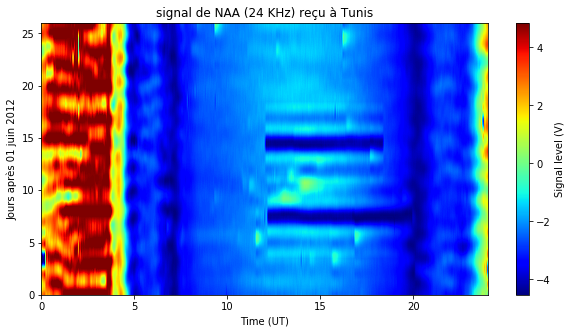

```python
import matplotlib.cm as cm
fig=plt.figure(figsize=(10,5))
plt.imshow(SID_Juin,interpolation='sinc', cmap=cm.jet,
           origin='lower',extent=[0, 24 , 0, 26],aspect='auto')
cb=plt.colorbar()
cb.set_label("Signal level (V)")
plt.xlabel("Time (UT)")
plt.ylabel("Jours après 01 juin 2012")
plt.title("signal de NAA (24 KHz) reçu à Tunis")
plt.show()
```

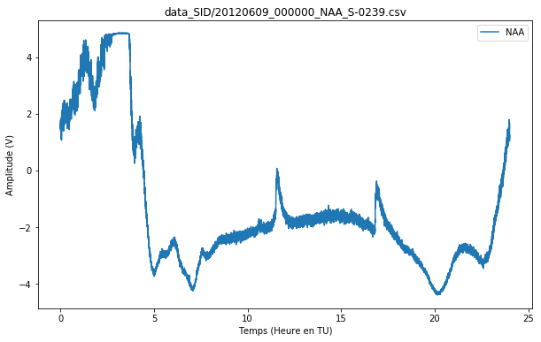

```python
PlotSID(NomFichier="data_SID/20120609_000000_NAA_S-0239.csv")
```

## Classification en intensité d’une éruption solaire

Cette classification se base sur l’intensité des rayons X dans la bande de 0.1 à 0.8 nm comme cela est indiqué dans le tableau ci-dessous. Cette classification sert de référence pour évaluer et prévenir les éventuelles dommages pour la planète (c'est l'équivalent de l'échelle de Richter pour les tremblements de Terre).

| Classe | Intensité ($Watts/m^2$) |
| --- | --- |
| A | I $<10^{-7}$ |
| B | $10^{-7} \leq $ I $<10^{-6}$ |
| C | $10^{-6} \leq $ I $<10^{-5}$ |
| M | $10^{-5} \leq $ I $<10^{-4}$ |
| X | I $\geq 10^{-4}$ |

## Les éruptions solaires en juin 2012

Un moyen très rapide de visualiser les données du satellite GOES pour tout le mois de juin 2012 est d'utiliser l'application web sur le site web "*Aurora forecast for Germany*": http://www.polarlicht-vorhersage.de/goes_archive :

[figure not shown]

## Charger des données *GOES* depuis des sites Web

Nous pouvons téléchargé les enregistrements du statellite GOES à partir du lien suivant: http://darts.jaxa.jp/pub/sswdb/goes/xray/

```python
# %load programs/PlotGOES_URL.py
import numpy as np
import matplotlib.pyplot as plt
import urllib.request
def PlotGOES_URL(date="", res="",source=""):

    url="http://darts.jaxa.jp/pub/sswdb/goes/xray/"+date+"_"+source+"_xr_"+res+".txt"
    # If you wish to retrieve a resource via URL and store it in a temporary location,
    # you can do so via the urlretrieve() function:
    local_filename, headers = urllib.request.urlretrieve(url)
    file = open(local_filename)
    dataGOESS,dataGOESL =np.loadtxt(file, skiprows=18, usecols=[6,7],unpack=True)

    data_length2 = len(dataGOESL) #
    time_data2   = np.arange(0.0, 24.0 , 24.0/(data_length2))
    plt.figure(figsize=(10,5))
    plt.plot(time_data2, dataGOESL,color='r',linewidth=3,label="GOES: Long X-Ray (0.1 - 0.8 nanometer)")
    plt.plot(time_data2, dataGOESS,color='k',linewidth=3,label="GOES: Short X-Ray (0.05 - 0.4 nanometer)", alpha=.3)
    plt.title(" GOES Solar X-ray Flux", fontsize=16, weight="bold" )
    plt.yscale('log')
    plt.ylabel("X ray Flux ($Watts/m^2$)")
    plt.ylim(1E-8,1E-2)
    plt.legend(loc='upper left')
    plt.tight_layout()
    plt.grid()
    plt.show()
```

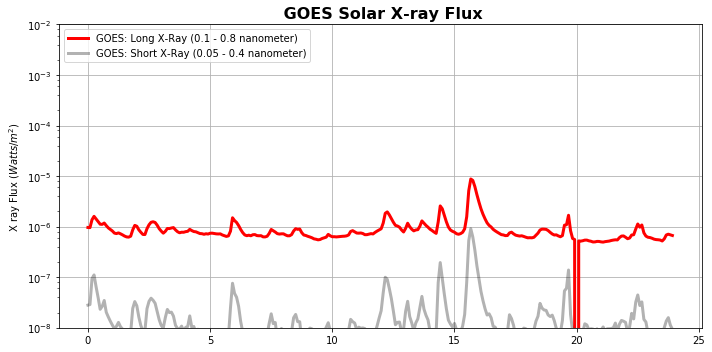

```python
PlotGOES_URL(date="20120607", res="5m",source="Gp")
```